# Exploration of the ‘people’ attribute in EDH dataset

Petra Hermankova

22/10/2020

# 1 Initial setup

## 1.1 Setup of the environment:

```r
devtools::install_github("sdam-au/sdam") # loading SDAM custom package, if not working try devtools::install_github("mplex/cedhar", subdir="pkg/sdam")
#devtools::install_github("mplex/cedhar", subdir="pkg/sdam")
library(tidyverse)
library(sdam)
library(jsonlite)
library(getPass)
library(formatR)
library(leaflet)
```

## 1.2 Loading data

1. Load the dataset, if you have Sciencedata.dk credentials

```r
resp = request("EDH_attrs_cleaned_2020-09-30.json", path="/sharingin/648597@au.dk/SDAM_root/SDAM_data/EDH/public", method="GET", cred=mycred_secret)
```

2. Make a list and tibble from the request function

```r
list_json <- jsonlite::fromJSON(resp)
EDH_tibble <- as_tibble(list_json)
```

3. Display the first 6 records

```r
head(EDH_tibble)
```

| responsible_individual | type_of_inscription | letter_size | not_after | literature | work_status | height | diplomatic_text | people | depth | material | type_of_monument | province_label | width | transcription | country | uri | findspot_ancient | last_update | modern_region | findspot_modern | language | id | edh_geography_uri | commentary | trismegistos_uri | not_before | findspot | year_of_find | present_location | … |
| --- | --- | --- | --- | --- | --- | --- | --- | --- | --- | --- | --- | --- | --- | --- | --- | --- | --- | --- | --- | --- | --- | --- | --- | --- | --- | --- | --- | --- | --- | --- |
| Feraudi | epitaph | 3.2-2 cm | 0130 | AE 1983, 0192.; M. Annecchino, Puteoli 4/5, 1980/81, 286-287, Nr. 17; fig. 17. (C) - AE 1983. | provisional | 33 cm | D M / NONIAE P F OPTATAE / ET C IVLIO ARTEMONI / PARENTIBVS / LIBERTIS LIBERTABVSQVE / POSTERISQVE EORVM / C IVLIVS C F OPTATVS / FILIVS |  | 2.7 cm | Marmor, geädert / farbig | tabula | Latium et Campania (Regio I) | 34 cm | D(is) M(anibus) / Noniae P(ubli) f(iliae) Optatae / et C(aio) Iulio Artemoni / parentibus / libertis libertabusque / posterisque eorum / C(aius) Iulius C(ai) f(ilius) Optatus / filius | Italy | https://edh-www.adw.uni-heidelberg.de/edh/inschrift/HD000001 | Cumae, bei | 2014-04-07 | Campania | Cuma, bei | Latin | HD000001 | https://edh-www.adw.uni-heidelberg.de/edh/geographie/11843 | (C): 2. Hälfte 1. - Anfang 2. Jh. - AE; Ende 1. - 1. Hälfte 2. Jh. - Annecchino. | https://www.trismegistos.org/text/251193 | 0071 | NA | NA | NA | … |
| Feraudi | epitaph | 4 cm | 0200 | AE 1983, 0080. (A); A. Ferrua, RAL 36, 1981, 109, Nr. 7. - AE 1983. | no image | 28 cm | C SEXTIVS PARIS / QVI VIXIT / ANNIS LXX |  | NA | marble: rocks - metamorphic rocks | tabula | Roma | 85 cm | C(aius) Sextius Paris / qui vixit / annis LXX | Italy | https://edh-www.adw.uni-heidelberg.de/edh/inschrift/HD000002 | Roma | 2014-04-07 | Lazio | Roma | Latin | HD000002 | https://edh-www.adw.uni-heidelberg.de/edh/geographie/19482 | AE 1983: Breite: 35 cm. | https://www.trismegistos.org/text/265631 | 0051 | Via Nomentana, S. Alessandro, Kirche | 1937 | NA | … |
| Feraudi | honorific inscription | 4.5-3 cm | 0170 | AE 1983, 0518. (B); J. González, ZPE 52, 1983, 172-173; Taf. 5b. (B) - AE. | provisional | (37) cm | [ ]VMMIO [ ] / [ ]ISENNA[ ] / [ ] XV[ ] / [ ] / [ |  | (12) cm | marble: rocks - metamorphic rocks | statue base | Baetica | (34) cm | [P(ublio) M]ummio [P(ubli) f(ilio)] / [Gal(eria) S]isenna[e Ru]/[tiliano] Xv[ir(o) stli]/[tibus iudicandis ---] / [------ | Spain | https://edh-www.adw.uni-heidelberg.de/edh/inschrift/HD000003 | NA | 2006-08-31 | Sevilla | Tomares | Latin | HD000003 | https://edh-www.adw.uni-heidelberg.de/edh/geographie/2694 | (B): [S]isenna ist falscher Kasus; folgende Ergänzung notwendig: [S]isenna[e]. Y: Text bezieht sich eher auf P. Mummius P.f. Sisenna Rutilianus (cos. suff. 146) als auf dessen Vater P. Mummius Sisenna… | https://www.trismegistos.org/text/220675 | 0131 | NA | before 1975 | Sevilla, Privatbesitz | … |
| Gräf | votive inscription | 2.5 cm | 0200 | AE 1983, 0533. (B); A.U. Stylow, Gerión 1, 1983, 267-273, Nr. 1; fig. 1. - AE 1983.; CIL 02, 01638. (B); CIL 02 (2. Aufl.) 05, 00274; Foto. | checked with photo | (39) cm | [ ]AVS[ ]LLA / M PORCI NIGRI SER / DOMINAE VENERI / ARAM POSVIT |  | 18 cm | limestone: rocks - clastic sediments | altar | Baetica | 27 cm | [---?]AV(?)S(?)[---]L(?)L(?)A / M(arci) Porci Nigri ser(va) / dominae Veneri / aram posuit | Spain | https://edh-www.adw.uni-heidelberg.de/edh/inschrift/HD000004 | Ipolcobulcula | 2015-03-27 | Córdoba | Carcabuey | Latin | HD000004 | https://edh-www.adw.uni-heidelberg.de/edh/geographie/2240 | Material: lokaler grauer Kalkstein. (B): Stylow, AE 1983: Z. 1: A[---]L(?)L(?)A; CIL II 1638: Z. 1: Aemilia; Z. 2: Mar[--] Iponubensis(?); Z. 3: Veneris. | https://www.trismegistos.org/text/222102 | 0151 | NA | before 1979 | Carcabuey, Grupo Escolar | … |
| Feraudi | epitaph | NA | 0200 | AE 1983, 0078. (B); A. Ferrua, RAL 36, 1981, 108, Nr. 3. - AE 1983. | no image | NA | [ ] L SVCCESSVS / [ ] L L IRENAEVS / [ ] C L TYCHES / [ ]VNT / [ ]RENTI F |  | NA | NA | stele | Roma | NA | [---] l(ibertus) Successus / [---] L(uci) l(ibertus) Irenaeus / [---] C(ai) l(iberta) Tyches(!) / [---]unt / [--- me]renti f(---) | Italy | https://edh-www.adw.uni-heidelberg.de/edh/inschrift/HD000005 | Roma | 2010-01-04 | Lazio | Roma | Latin | HD000005 | https://edh-www.adw.uni-heidelberg.de/edh/geographie/19428 | (B): Z. 3: C(ai) l(ibertae) Tyches. | https://www.trismegistos.org/text/265629 | 0001 | Via Cupa (ehem. Vigna Nardi) | NA | NA | … |
| Gräf | epitaph | 7-4 cm | 0150 | AE 1983, 0524. (B); P. Rodríguez Oliva - R. Atencia Páez, BSEAA 49, 1983, 154, Nr. 3; lám. 3,2. (B) - AE 1983.; CIL 02 (2. Aufl.) 05, 00883. | checked with photo | 145 cm | D M S / / MEMMIA AVCTIN[ ] / AN LXX PIA IN SVIS / H S E S T TE[ ] L |  | 15 cm | limestone: rocks - clastic sediments | stele | Baetica | 60 cm | D(is) M(anibus) s(acrum) // Memmia Auctin[a] / an(norum) LXX pia in suis / h(ic) s(ita) e(st) s(it) t(ibi) te[r(ra)] l(evis) | Spain | https://edh-www.adw.uni-heidelberg.de/edh/inschrift/HD000006 | Sabora, bei | 2011-06-10 | Málaga | Cañete la Real | Latin | HD000006 | https://edh-www.adw.uni-heidelberg.de/edh/geographie/2999 | Der Stein ist aus 2 aneinanderpassenden Fragmenten zusammengesetzt. Z. 1 befindet sich oberhalb des gerahmten Inschriftfeldes. (B): Rodríguez Oliva - Atencia, AE 1983: Z. 4: t(erra). | https://www.trismegistos.org/text/222924 | 0071 | Huerta Nueva | 1974 | Cañete la Real | … |

# 2 Exploration of the attribute ‘People’ using tidyverse solution

0. What are names of all attributes within the ‘people’ attribute
1. How many people are in total in the EDH database?
2. How many people there are per inscription (average, min, max)
3. What is the gender ratio of people on inscriptions? (male, female, NA)
4. What are the names of unique values in the ‘status’ attribute?
5. What is the ratio of different statuses, e.g. slave vs freedman
6. How many inscriptions have ‘Age’ category?
7. What is the average age of people (years, months, days)

When I have the pointers how to get the data out of ‘people’ I will be looking at the following specific cases:

Specific case (funerary inscriptions; attribue ‘type_of_inscription_clean’ == ‘epitaph’) 1. How many people are on funerary inscriptions (total, average, min, max) 2. What is the ratio of genders on funerary inscriptions (male, female, NA) 3. What is the age of people on funerary inscriptions (total number of insc with age, average, min, max) 4. What is the average age of people on funerary inscriptions by province

Specific case (gender composition) 1. Ratio of men/women on different types of inscriptions (attribue ‘type_of_inscription_clean’)

```r
EDH_unnested<- EDH_tibble %>%
  unnest(people)
```

## 2.1 What are names of all attributes within the ‘people’ attribute

```r
setdiff(names(EDH_unnested), names(EDH_tibble))
```

```
##  [1] "name"        "cognomen"    "nomen"       "person_id"   "gender"
##  [6] "praenomen"   "age: years"  "tribus"      "status"      "occupation"
## [11] "origo"       "age: days"   "age: months" "supernomen"  "age: hours"
```

## 2.2 How many people are in total in the EDH database?

One way through gender

```r
EDH_unnested %>%
  count(gender, sort = TRUE) -> gender
sum(gender$n)
```

```
## [1] 92427
```

Second way through nrow

```r
nrow(EDH_unnested)
```

```
## [1] 92427
```

## 2.3 How many people there are per inscription (average, min, max)

```r
summary(as.numeric(EDH_unnested$person_id))
```

```
##    Min. 1st Qu.  Median    Mean 3rd Qu.    Max.
##   1.000   1.000   2.000   4.233   3.000 244.000
```

## 2.4 What is the gender ratio of people on inscriptions? (male, female, NA)

```r
EDH_unnested %>%
  count(gender, sort = TRUE)
```

| gender | n |
| --- | --- |
| male | 59747 |
| NA | 18075 |
| female | 14564 |
| M? | 26 |
| W? | 15 |

## 2.5 What are the names of unique values in the ‘status’ attribute?

```r
EDH_unnested$status %>%
  unique()
```

```
##  [1] NA
##  [2] "senatorial order"
##  [3] "slaves"
##  [4] "freedmen / freedwomen"
##  [5] "freedmen / freedwomen?"
##  [6] "slaves?"
##  [7] "senatorial order?"
##  [8] "decurial order, higher local offices"
##  [9] "military personnel"
## [10] "equestrian order"
## [11] "decurial order, higher local offices?"
## [12] "equestrian order?"
## [13] "military personnel?"
## [14] "Augustales"
## [15] "emperor / imperial household?"
```

[output cut: 35 more lines]

## 2.6 What is the ratio of different statuses, e.g. slave vs freedman

```r
str_split_fixed(EDH_unnested$status, ";", n=3) %>%
  as.data.frame() -> status

status %>%
  cbind(combined = c(status$V1,status$V2,status$V3)) %>%
  filter(combined != "") %>%
  mutate(combined_clean = str_replace_all(string = combined, pattern = "\\?", replacement = "")) %>%
  mutate(combined_clean = str_replace_all(string = combined_clean, pattern = "^ ", replacement = "")) %>%
  count(combined_clean, sort=TRUE) -> status_counts

status_counts
```

| combined_clean | n |
| --- | --- |
| military personnel | 9983 |
| senatorial order | 5092 |
| freedmen / freedwomen | 3627 |
| decurial order, higher local offices | 2186 |
| equestrian order | 1750 |
| slaves | 1258 |
| Augustales | 651 |
| lower local offices, administration of imperial estates | 289 |
| rulers (foreign) | 53 |
| emperor / imperial household | 33 |

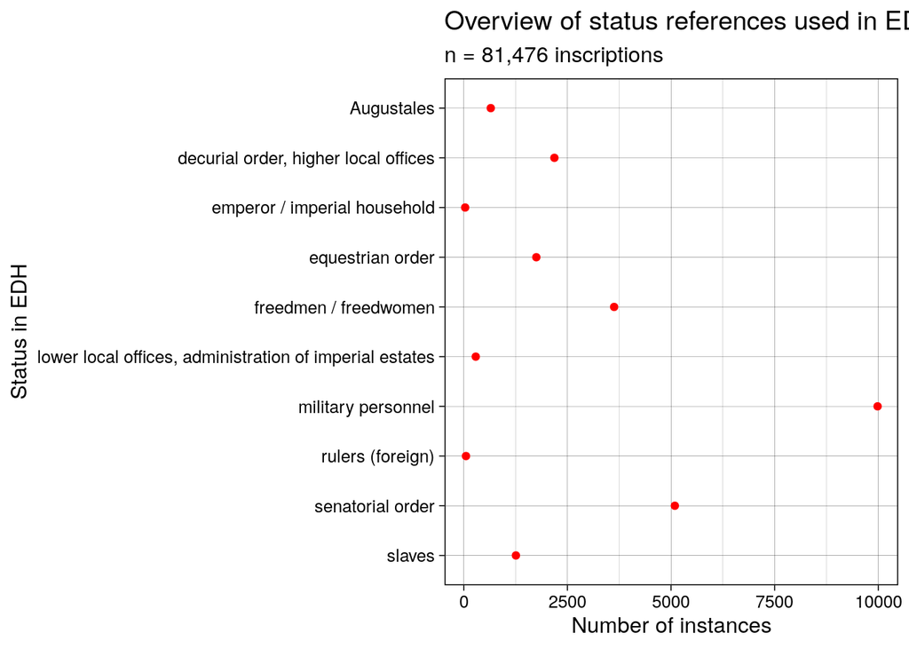

```r
status_counts %>%
  #sort(status_counts$combined_clean) %>%
  ggplot(aes(y=fct_rev(combined_clean), x=n), size = n) +
  geom_point(color="red") +
  labs(x = "Number of instances", y = "Status in EDH", title = "Overview of status references used in EDH dataset", subtitle = "n = 81,476 inscriptions" ) +
    theme_linedraw(base_size = 12)
```

## 2.7 How many inscriptions have ‘Age’ category?

```r
EDH_unnested %>%
  select('age: days', 'age: months', 'age: hours', 'age: years') %>%
  filter(!is.na(EDH_unnested$`age: years`) | !is.na(EDH_unnested$`age: months`) | !is.na(EDH_unnested$`age: days`) |!is.na(EDH_unnested$`age: hours`))
```

| age: days | age: months | age: hours | age: years |
| --- | --- | --- | --- |
| NA | NA | NA | 70 |
| NA | NA | NA | 70 |
| 17 | NA | NA | 42 |
| NA | at least 5 | NA | 18 |
| NA | 6 | NA | 8 |
| NA | NA | NA | at least 20 |
| NA | NA | NA | 35 |
| NA | NA | NA | 34 |
| NA | 2 | NA | 5 |
| 14 | 3 | NA | 10 |

[output cut: 8111 more lines]

What are the unique values for years

```r
unique(EDH_unnested$`age: years`)
```

```
##   [1] NA                   "70"                 "42"
##   [4] "18"                 "8"                  "at least 20"
##   [7] "35"                 "34"                 "5"
##  [10] "10"                 "25"                 "55"
##  [13] "at least 10"        "2"                  "1"
##  [16] "64"                 "53"                 "36"
##  [19] "29"                 "15"                 "40"
##  [22] "30"                 "7"                  "75"
##  [25] "4"                  "100"                "19"
##  [28] "50"                 "at least 21"        "23"
##  [31] "26"                 "27"                 "60"
##  [34] "14"                 "24"                 "90"
##  [37] "20"                 "43"                 "data not available"
##  [40] "16"                 "37"                 "22"
##  [43] "3"                  "at least 40"        "45"
```

[output cut: 39 more lines]

How many people have their age stated in years

```r
sum(!is.na(EDH_unnested$`age: years`))
```

```
## [1] 7993
```

```r
EDH_unnested %>%
  select('age: days', 'age: months', 'age: hours', 'age: years') %>%
  filter(!is.na(EDH_unnested$`age: years`))
```

| age: days | age: months | age: hours | age: years |
| --- | --- | --- | --- |
| NA | NA | NA | 70 |
| NA | NA | NA | 70 |
| 17 | NA | NA | 42 |
| NA | at least 5 | NA | 18 |
| NA | 6 | NA | 8 |
| NA | NA | NA | at least 20 |
| NA | NA | NA | 35 |
| NA | NA | NA | 34 |
| NA | 2 | NA | 5 |
| 14 | 3 | NA | 10 |

[output cut: 7983 more lines]

How many people have their age stated in months

```r
sum(!is.na(EDH_unnested$`age: months`))
```

```
## [1] 928
```

```r
EDH_unnested %>%
  select('age: days', 'age: months', 'age: hours', 'age: years') %>%
  filter(!is.na(EDH_unnested$`age: months`))
```

| age: days | age: months | age: hours | age: years |
| --- | --- | --- | --- |
| NA | at least 5 | NA | 18 |
| NA | 6 | NA | 8 |
| NA | 2 | NA | 5 |
| 14 | 3 | NA | 10 |
| 5 | 7 | NA | 2 |
| 9 | 6 | NA | 1 |
| 14 | 9 | NA | 7 |
| 4 | 9 | NA | 1 |
| data not available | 5 | NA | 4 |
| NA | 5 | NA | 1 |

[output cut: 918 more lines]

How many people have their age stated in days

```r
sum(!is.na(EDH_unnested$`age: days`))
```

```
## [1] 689
```

```r
EDH_unnested %>%
  select('age: days', 'age: months', 'age: hours', 'age: years') %>%
  filter(!is.na(EDH_unnested$`age: days`))
```

| age: days | age: months | age: hours | age: years |
| --- | --- | --- | --- |
| 17 | NA | NA | 42 |
| 14 | 3 | NA | 10 |
| 5 | 7 | NA | 2 |
| 9 | 6 | NA | 1 |
| 11 | NA | NA | 30 |
| 14 | 9 | NA | 7 |
| 4 | 9 | NA | 1 |
| data not available | 5 | NA | 4 |
| 24 | 10 | NA | 10 |
| 21 | 3 | NA | 25 |

[output cut: 679 more lines]

How many people have their age stated in hours

```r
sum(!is.na(EDH_unnested$`age: hours`))
```

```
## [1] 24
```

```r
EDH_unnested %>%
  select('age: days', 'age: months', 'age: hours', 'age: years') %>%
  filter(!is.na(EDH_unnested$`age: hours`))
```

| age: days | age: months | age: hours | age: years |
| --- | --- | --- | --- |
| NA | 3 | 3 | 3 |
| 19 | at least 1 | 6 | 2 |
| 5 | 10 | 5 | 4 |
| 9 | 11 | 8 | 11 |
| 7 | 6 | 3 | 15 |
| 24 | 1 | 7 | 44 |
| NA | NA | 10 | NA |
| 18 | 7 | 6 | 5 |
| 8 | 1 | 9 | 45 |
| 12 | 7 | 11 | 12 |

[output cut: 14 more lines]

## 2.8 What is the average age of people (years, months, days)

Not ideal method as it skips a lot of textual descriptions

```r
summary(as.numeric(EDH_unnested$`age: years`))
```

```
##    Min. 1st Qu.  Median    Mean 3rd Qu.    Max.    NA's
##    1.00   18.00   30.00   33.66   50.00  200.00   85548
```

```r
summary(as.numeric(EDH_unnested$`age: months`))
```

```
##    Min. 1st Qu.  Median    Mean 3rd Qu.    Max.    NA's
##    1.00    3.00    6.00    5.91    8.00   30.00   91583
```

```r
summary(as.numeric(EDH_unnested$`age: days`))
```

```
##    Min. 1st Qu.  Median    Mean 3rd Qu.    Max.    NA's
##     1.0     7.0    13.0    14.5    20.0   100.0   91819
```

```r
summary(as.numeric(EDH_unnested$`age: hours`))
```

```
##    Min. 1st Qu.  Median    Mean 3rd Qu.    Max.    NA's
##       3       4       6       6       8      11   92406
```

Better method using regular expressions to detect years and converting them as numeric

```r
EDH_unnested %>%
  select('age: days', 'age: months', 'age: hours', 'age: years') %>%
  mutate(age_years = as.numeric(str_extract(EDH_unnested$'age: years', pattern = "[:digit:]+"))) %>%
  mutate(age_months = as.numeric(str_extract(EDH_unnested$'age: months', pattern = "[:digit:]+"))) %>%
  mutate(age_days = as.numeric(str_extract(EDH_unnested$'age: days', pattern = "[:digit:]+"))) %>%
  mutate(age_hours = as.numeric(str_extract(EDH_unnested$'age: hours', pattern = "[:digit:]+"))) -> ages
```

```r
summary(ages$age_years)
```

```
##    Min. 1st Qu.  Median    Mean 3rd Qu.    Max.    NA's
##     1.0    17.0    30.0    32.7    46.0   200.0   84958
```

```r
summary(ages$age_months)
```

```
##    Min. 1st Qu.  Median    Mean 3rd Qu.    Max.    NA's
##    1.00    3.00    5.00    5.83    8.00   30.00   91546
```

```r
summary(ages$age_days)
```

```
##    Min. 1st Qu.  Median    Mean 3rd Qu.    Max.    NA's
##    1.00    7.00   13.00   14.34   20.00  100.00   91780
```

```r
summary(ages$age_hours)
```

```
##    Min. 1st Qu.  Median    Mean 3rd Qu.    Max.    NA's
##    3.00    4.25    6.00    5.95    7.75   11.00   92405
```

# 3 More complex questions

## 3.1 What is the age of people on funerary inscriptions by province

```r
EDH_unnested %>%
  filter(type_of_inscription_clean == "epitaph") -> epitaph
```

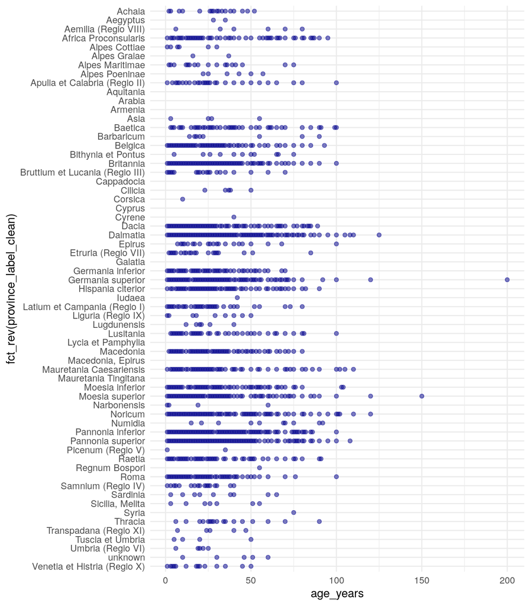

```r
epitaph %>%
  select(`age: years`, province_label_clean) %>%
  mutate(age_years = as.numeric(str_extract(epitaph$'age: years', pattern = "[:digit:]+"))) %>%
  count(age_years, province_label_clean) %>%
  ggplot(aes(x=age_years, y= fct_rev(province_label_clean))) + geom_point(alpha=0.5, color="darkblue") +
  theme_minimal()
```

```r
dir.create("../figures")
ggsave("../figures/Age_years_provinces.png", width = 8, height = 8)
```

## 3.2 What is the average age of people on funerary inscriptions by province

```r
epitaph %>%
  select(`age: years`, province_label_clean) %>%
  mutate(age_years = as.numeric(str_extract(epitaph$'age: years', pattern = "[:digit:]+"))) -> epitaph
epitaph
```

| age: years | province_label_clean | age_years |
| --- | --- | --- |
| NA | Latium et Campania (Regio I) | NA |
| NA | Latium et Campania (Regio I) | NA |
| NA | Latium et Campania (Regio I) | NA |
| 70 | Roma | 70 |
| NA | Roma | NA |
| NA | Roma | NA |
| NA | Roma | NA |
| 70 | Baetica | 70 |
| NA | Roma | NA |
| NA | Roma | NA |

[output cut: 9990 more lines]

```r
# frequency of with which people state the age in years by provinces
epitaph %>%
  na.omit(age_years) %>%
  count(province_label_clean, sort = TRUE)
```

| province_label_clean | n |
| --- | --- |
| Dalmatia | 1606 |
| Pannonia superior | 980 |
| Noricum | 891 |
| Pannonia inferior | 607 |
| Germania superior | 494 |
| Moesia superior | 316 |
| Britannia | 272 |
| Dacia | 252 |
| Hispania citerior | 195 |
| Macedonia | 190 |

[output cut: 44 more lines]

```r
# install.packages("psych")
library(psych)
describeBy(epitaph$age_years, group = epitaph$province_label_clean, mat = TRUE, digits = 2) -> age_provinces
head(age_provinces)
```

|  | item | group1 | vars | n | mean | sd | median | trimmed | mad | min | max | range | skew | kurtosis | se |
| --- | --- | --- | --- | --- | --- | --- | --- | --- | --- | --- | --- | --- | --- | --- | --- |
| X11 | 1 | Achaia | 1 | 34 | 27.71 | 13.47 | 30.0 | 28.21 | 11.86 | 2 | 52 | 50 | -0.49 | -0.76 | 2.31 |
| X12 | 2 | Aegyptus | 1 | 2 | 31.50 | 4.95 | 31.5 | 31.50 | 5.19 | 28 | 35 | 7 | 0.00 | -2.75 | 3.50 |
| X13 | 3 | Aemilia (Regio VIII) | 1 | 6 | 48.00 | 27.33 | 50.0 | 48.00 | 28.17 | 6 | 80 | 74 | -0.27 | -1.66 | 11.16 |
| X14 | 4 | Africa Proconsularis | 1 | 112 | 44.04 | 28.00 | 40.0 | 43.69 | 35.58 | 1 | 95 | 94 | 0.08 | -1.30 | 2.65 |
| X15 | 5 | Alpes Cottiae | 1 | 6 | 12.33 | 12.13 | 7.5 | 12.33 | 8.15 | 1 | 30 | 29 | 0.47 | -1.86 | 4.95 |
| X16 | 6 | Alpes Graiae | 1 | 2 | 26.50 | 14.85 | 26.5 | 26.50 | 15.57 | 16 | 37 | 21 | 0.00 | -2.75 | 10.50 |

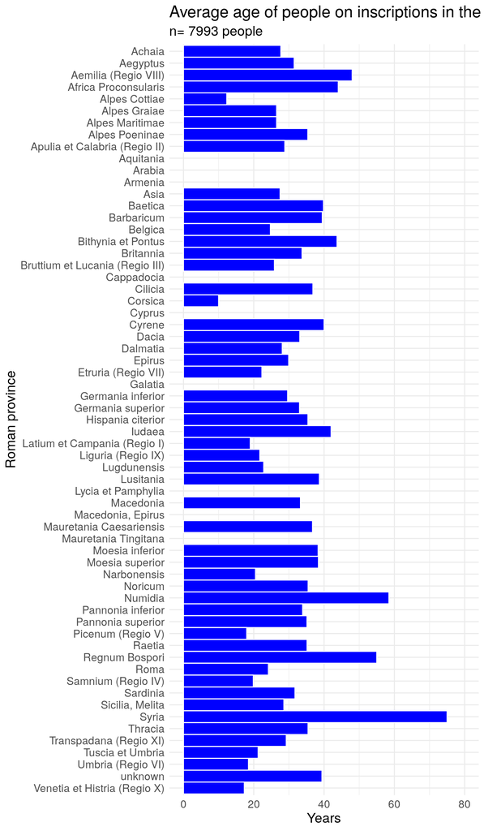

```r
age_provinces %>%
  select(group1, mean) %>%
  ggplot(aes(y=fct_rev(group1), x=mean)) +
  geom_col(color="white", fill="blue", width=1, stat="identity") +
  coord_cartesian(xlim=c(0,80)) +
  theme_minimal() +
  theme(text = element_text(size=14)) +
  labs(y="Roman province", x="Years", title= "Average age of people on inscriptions in the EDH database", subtitle = "n= 7993 people" ) +

ggsave("../figures/Age_average_years_provinces.png", width = 12, height = 12)
```